# Spring 2023 GE 461 Introduction to Data Science

Elifnur Alsaç - Esad İsmail Tök

```r
library(RSQLite)  ## if package is not on the computer, then install it only once using Tools > Install packages...
con <- dbConnect(SQLite(), "../data/dodgers.sqlite") # read Modern Data Science with R for different ways to connect a database.

#dbListTables(con)

tbl(con, "events") %>%
  collect() %>%
  mutate(day_of_week = factor(day_of_week, levels = c("Monday", "Tuesday", "Wednesday", "Thursday", "Friday", "Saturday", "Sunday")),
         month = factor(month, levels = c("APR","MAY","JUN","JUL","AUG","SEP","OCT"))) %>%
  mutate_if(is.character, factor) %>%
  mutate(temp = round((temp- 32)*5/9)) -> events
```

## Data exploration

```r
head(events)
```

```
## # A tibble: 6 × 12
##   month   day attend day_of_week opponent  temp skies  day_night cap   shirt
##   <fct> <dbl>  <dbl> <fct>       <fct>    <dbl> <fct>  <fct>     <fct> <fct>
## 1 APR      10  56000 Tuesday     Pirates     19 Clear  Day       NO    NO
## 2 APR      11  29729 Wednesday   Pirates     14 Cloudy Night     NO    NO
## 3 APR      12  28328 Thursday    Pirates     14 Cloudy Night     NO    NO
## 4 APR      13  31601 Friday      Padres      12 Cloudy Night     NO    NO
## 5 APR      14  46549 Saturday    Padres      14 Cloudy Night     NO    NO
## 6 APR      15  38359 Sunday      Padres      18 Clear  Day       NO    NO
## # ℹ 2 more variables: fireworks <fct>, bobblehead <fct>
```

```r
sum(is.na(events))
```

```
## [1] 0
```

```r
summary(events)
```

```
##  month         day            attend         day_of_week      opponent
##  APR:12   Min.   : 1.00   Min.   :24312   Monday   :12   Giants   : 9
##  MAY:18   1st Qu.: 8.00   1st Qu.:34493   Tuesday  :13   Padres   : 9
##  JUN: 9   Median :15.00   Median :40284   Wednesday:12   Rockies  : 9
##  JUL:12   Mean   :16.14   Mean   :41040   Thursday : 5   Snakes   : 9
##  AUG:15   3rd Qu.:25.00   3rd Qu.:46588   Friday   :13   Cardinals: 7
##  SEP:12   Max.   :31.00   Max.   :56000   Saturday :13   Brewers  : 4
##  OCT: 3                                   Sunday   :13   (Other)  :34
##       temp          skies    day_night   cap     shirt    fireworks bobblehead
##  Min.   :12.00   Clear :62   Day  :15   NO :79   NO :78   NO :67    NO :70
##  1st Qu.:19.00   Cloudy:19   Night:66   YES: 2   YES: 3   YES:14    YES:11
##  Median :23.00
##  Mean   :22.84
##  3rd Qu.:26.00
##  Max.   :35.00
##
```

As we can see from the summary, we have 12 column and 81 row in our data. Also, we do not have any NA elements in our data set.

```r
events %>% names()
```

```
##  [1] "month"       "day"         "attend"      "day_of_week" "opponent"
##  [6] "temp"        "skies"       "day_night"   "cap"         "shirt"
## [11] "fireworks"   "bobblehead"
```

- We examined the relationship between “attend” and some parameters on the Dodgers data set. Among the ones we reviewed are temp, bobblehead, month, skies, and day_night. In the class, as we examined, there is a statistically significant relationship between temp and bobblehead and attendance. In addition, we can say that there is a significant relationship between month and the number of attendance. In this report, we will first try to understand the relationship between attendance and the parameters that we did not examine in the lesson, and then we will make the best model for attendance, and while doing this, we will proceed by analyzing the models. After that we will make our prediction within the 90% confidence interval.
- Lets try to understand what is the relationship between “attendance” and “opponent”.

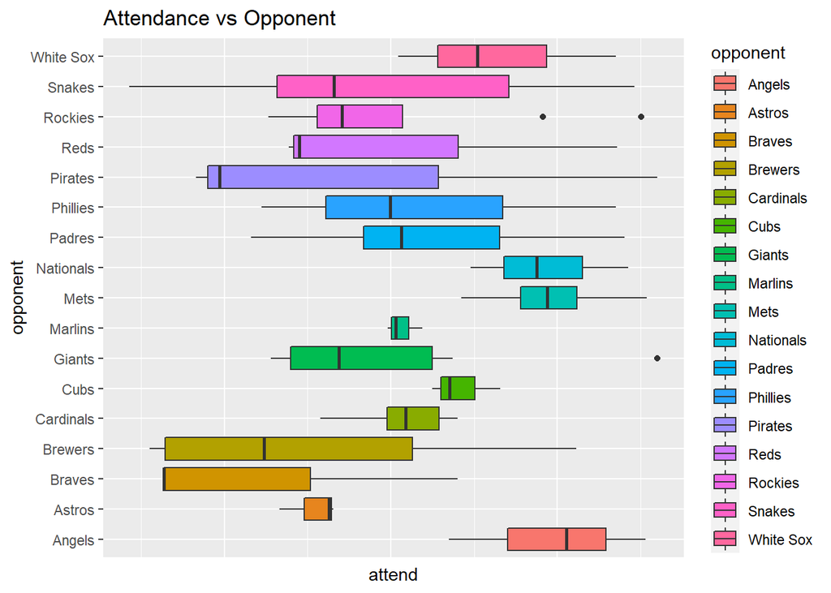

```r
g1 <- ggplot(events, aes(x = attend, y = opponent, fill = opponent)) +
   geom_boxplot() +
   theme(axis.text.x=element_blank(),
   axis.ticks.x=element_blank()) +
   ggtitle("Attendance vs Opponent")

g1
```

As we can see from the graph of Attendance vs Opponent, Angels has the maximum attendance when it is the opponent, and Braves has the minimum attendance.

- Lets try to understand whether “day” has affect on the “attend”.

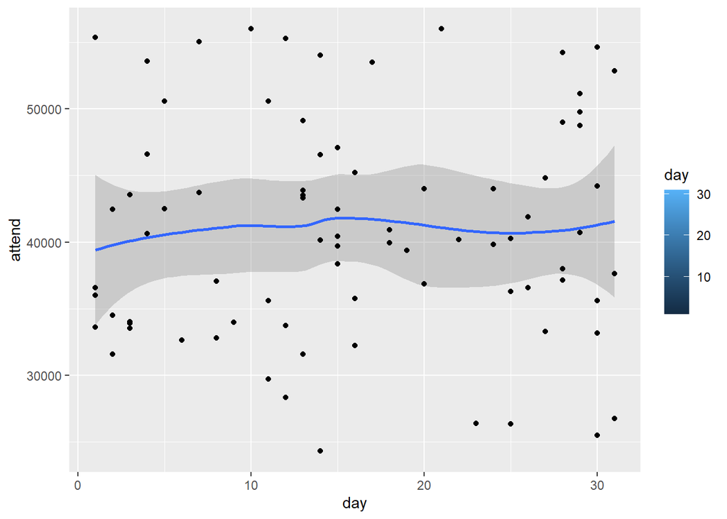

```r
g2 <- ggplot(events, aes(x = day, y = attend, fill = day)) +
   geom_smooth() + geom_point()
   ggtitle("Attendance vs Day")
## $title
## [1] "Attendance vs Day"
##
## attr(,"class")
## [1] "labels"

g2
## `geom_smooth()` using method = 'loess' and formula 'y ~ x'
```

Since the line is “almost” straight, we can say that “day” has no affect on the “attend”.

- We also need to see the affect of the “firework”, “cap”, and “shirt” in the dataset.

```r
events %>%
  count(bobblehead, fireworks, cap, shirt)
```

```
## # A tibble: 5 × 5
##   bobblehead fireworks cap   shirt     n
##   <fct>      <fct>     <fct> <fct> <int>
## 1 NO         NO        NO    NO       51
## 2 NO         NO        NO    YES       3
## 3 NO         NO        YES   NO        2
## 4 NO         YES       NO    NO       14
## 5 YES        NO        NO    NO       11
```

```r
events %>%
  count(shirt, month) %>%
  pivot_wider(names_from = shirt, values_from = n) %>%
  pander(caption = "Number of games played in each month when shirt is given and not given")
```

Number of games played in each month when shirt is given and not given

| month | NO | YES |
| --- | --- | --- |
| APR | 11 | 1 |
| MAY | 18 | NA |
| JUN | 8 | 1 |
| JUL | 12 | NA |
| AUG | 15 | NA |
| SEP | 11 | 1 |
| OCT | 3 | NA |

```r
events %>%
  count(cap, month) %>%
  pivot_wider(names_from = cap, values_from = n) %>%
  pander(caption = "Number of games played in each month when cap is given and not given")
```

Number of games played in each month when cap is given and not given

| month | NO | YES |
| --- | --- | --- |
| APR | 12 | NA |
| MAY | 18 | NA |
| JUN | 9 | NA |
| JUL | 11 | 1 |
| AUG | 14 | 1 |
| SEP | 12 | NA |
| OCT | 3 | NA |

```r
events %>%
  count(fireworks, month) %>%
  pivot_wider(names_from = fireworks, values_from = n) %>%
  pander(caption = "Number of games played in each month when fireworks are used and not used")
```

Number of games played in each month when fireworks are used and not used

| month | NO | YES |
| --- | --- | --- |
| APR | 10 | 2 |
| MAY | 15 | 3 |
| JUN | 7 | 2 |
| JUL | 10 | 2 |
| AUG | 12 | 3 |
| SEP | 10 | 2 |
| OCT | 3 | NA |

```r
events %>%
  count(bobblehead, month) %>%
  pivot_wider(names_from = bobblehead, values_from = n) %>%
  pander(caption = "Number of games played in each month when bobblehead is given and not given")
```

Number of games played in each month when bobblehead is given and not given As we can see from the tables, in the month of october shirt, cap and bobblehead is not given and firework is not used. Also in the month of september cap and bobblehead is not given. Also in the month of may cap and shirt is not given.

| month | NO | YES |
| --- | --- | --- |
| APR | 11 | 1 |
| MAY | 16 | 2 |
| JUN | 7 | 2 |
| JUL | 9 | 3 |
| AUG | 12 | 3 |
| SEP | 12 | NA |
| OCT | 3 | NA |

- In the class, we understand that bobblehead is an important parameter, and we want to understand other parameters’, such as cap, shirt and fireworks, affect on the attend. We can make some t.test to understand their effect.

```r
t.test(x=events$attend[events$cap=="YES"],
       y=events$attend[events$cap=="NO"])
```

```
##
##  Welch Two Sample t-test
##
## data:  events$attend[events$cap == "YES"] and events$attend[events$cap == "NO"]
## t = -0.66319, df = 1.0977, p-value = 0.619
## alternative hypothesis: true difference in means is not equal to 0
## 95 percent confidence interval:
##  -48408.87  42563.39
## sample estimates:
## mean of x mean of y
##  38189.50  41112.24
```

```r
t.test(x=events$attend[events$shirt=="YES"],
       y=events$attend[events$shirt=="NO"])
```

```
##
##  Welch Two Sample t-test
##
## data:  events$attend[events$shirt == "YES"] and events$attend[events$shirt == "NO"]
## t = 1.8187, df = 2.3992, p-value = 0.1891
## alternative hypothesis: true difference in means is not equal to 0
## 95 percent confidence interval:
##  -5969.71 17607.94
## sample estimates:
## mean of x mean of y
##  46643.67  40824.55
```

```r
t.test(x=events$attend[events$fireworks=="YES"],
       y=events$attend[events$fireworks=="NO"])
```

```
##
##  Welch Two Sample t-test
##
## data:  events$attend[events$fireworks == "YES"] and events$attend[events$fireworks == "NO"]
## t = 0.024331, df = 27.332, p-value = 0.9808
## alternative hypothesis: true difference in means is not equal to 0
## 95 percent confidence interval:
##  -3804.144  3895.500
## sample estimates:
## mean of x mean of y
##  41077.86  41032.18
```

We do not see a statistically significant difference between the average attendance of the games played when cap or shirt given and fireworks used. All of the parameter has big p-value(>0.05) which means they do not explain the attendance.

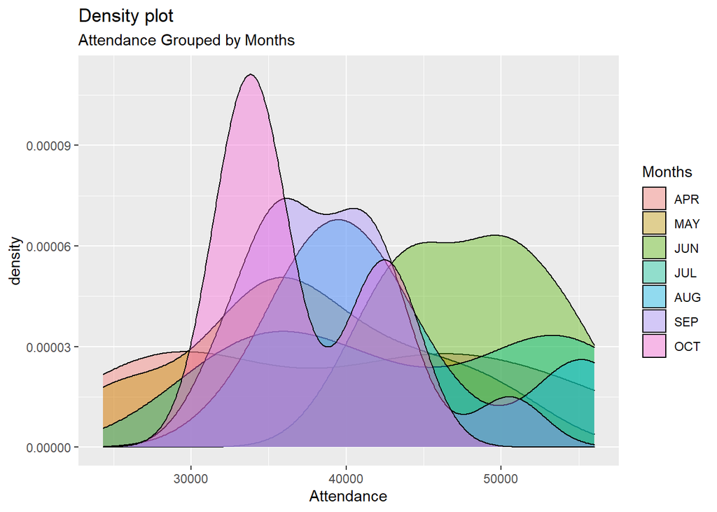

```r
# Change density plot fill colors by groups
g3 <- ggplot(events, aes(x=attend, fill=month)) +
  geom_density()
g3 <-ggplot(events, aes(x=attend, fill=month)) +
  geom_density(alpha=0.4) +
    labs(title="Density plot",
         subtitle="Attendance Grouped by Months",
         x="Attendance",
         fill="Months")
g3
```

* We want to understand what is the correlation between the parameters. Our data set is mostly consist of categorical variables. Therefore, we plot a matrix which shows the chi-sq table.

```r
library(lsr)
```

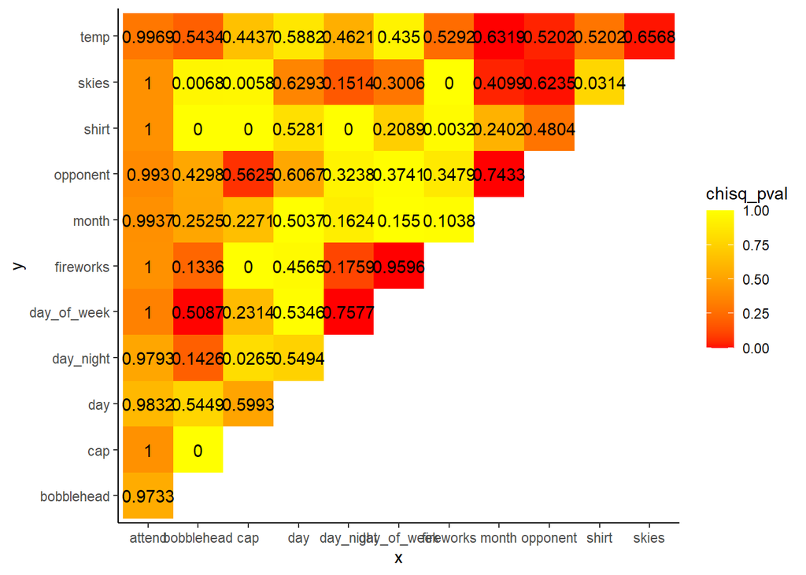

```r
suppressWarnings({
# function to get chi square p value and Cramers V
f = function(x,y) {
    tbl = events %>% select(x,y) %>% table()
    chisq_pval = round(chisq.test(tbl)$p.value, 4)
    cramV = round(cramersV(tbl), 4)
    data.frame(x, y, chisq_pval, cramV) }

# create unique combinations of column names
# sorting will help getting a better plot (upper triangular)
df_comb = data.frame(t(combn(sort(names(events)), 2)), stringsAsFactors = F)

# apply function to each variable combination
df_res = map2_df(df_comb$X1, df_comb$X2, f)

# plot results
df_res %>%
  ggplot(aes(x,y,fill=chisq_pval))+
  geom_tile()+
  geom_text(aes(x,y,label=cramV))+
  scale_fill_gradient(low="red", high="yellow")+
  theme_classic()
})
```

In the table above, we can see some correlation but indeed it may cause some misinterpreting the results since we have categorical values which have more than 2-levels and also some numeric variables. So we decided to use different method which is vif() test. Accordoing to vif() test, if the value is more than 5 than we can consider the collinearity of that variable. Collinearity tells us about a situation where two or more predictor variables are closely related to one another. This may cause a problem because independent variables should be independent. If the degree of correlation between variables is high enough, it can cause problems when we fit the model and interpret the results. In this situation we looked the gvif() results to understand the situation. Since our data has categorical variables and we can not use vif() directly. If the result of gvif() is more than 5, than we may consider it as collinearity occurs for that predictor.

```r
vif_model<-lm(attend~.,events)
car::vif(vif_model)
```

```
##                      GVIF Df GVIF^(1/(2*Df))
## month        15721.683478  6        2.237218
## day              4.122806  1        2.030469
## day_of_week    644.471445  6        1.714353
## opponent    155286.452559 16        1.452857
## temp             9.353453  1        3.058342
## skies            2.316014  1        1.521846
## day_night        4.407191  1        2.099331
## cap              1.878152  1        1.370457
## shirt            1.706222  1        1.306224
## fireworks       22.604096  1        4.754377
## bobblehead       2.728603  1        1.651848
```

Here, there is no value bigger than 5, but fireworks gvif() value is close to 5, which is 4,75. So we need to be careful when we examine fireworks parameter.

##Finding The Best Model

At first, we can start with all variables for our model.

```r
lm1<-lm(attend~., data = events)
lm1 %>% summary()
```

```
##
## Call:
## lm(formula = attend ~ ., data = events)
##
## Residuals:
##     Min      1Q  Median      3Q     Max
## -9071.5 -3105.3   -83.3  1398.1 12467.6
##
## Coefficients:
##                       Estimate Std. Error t value Pr(>|t|)
## (Intercept)           49144.43   14120.70   3.480  0.00114 **
## monthMAY               4562.82    6161.08   0.741  0.46288
## monthJUN              -2780.38   12052.35  -0.231  0.81862
## monthJUL               4725.36    6220.19   0.760  0.45150
## monthAUG               8631.58    7717.22   1.118  0.26943
## monthSEP               4296.83    7739.53   0.555  0.58158
## monthOCT               6217.52    9532.41   0.652  0.51763
## day                     134.00     141.29   0.948  0.34811
## day_of_weekTuesday     8670.34    2943.86   2.945  0.00514 **
## day_of_weekWednesday      6.94    2764.44   0.003  0.99801
## day_of_weekThursday     460.46    3897.62   0.118  0.90650
## day_of_weekFriday    -18358.17    9210.84  -1.993  0.05247 .
## day_of_weekSaturday    3674.93    3341.26   1.100  0.27737
## day_of_weekSunday       892.73    4810.77   0.186  0.85364
## opponentAstros       -20678.17   14211.96  -1.455  0.15277
## opponentBraves       -18497.20   13741.48  -1.346  0.18517
## opponentBrewers      -22322.21   15155.70  -1.473  0.14791
## opponentCardinals    -12532.09   13146.23  -0.953  0.34565
## opponentCubs         -10529.08   12640.84  -0.833  0.40938
## opponentGiants       -16880.09   13263.72  -1.273  0.20983
## opponentMarlins      -19147.75   13897.97  -1.378  0.17525
## opponentMets          -4234.12    6444.47  -0.657  0.51459
## opponentNationals     -5850.86   13928.61  -0.420  0.67649
## opponentPadres       -11169.54   11310.93  -0.988  0.32880
## opponentPhillies     -13698.94   12586.97  -1.088  0.28237
## opponentPirates      -12451.05   13301.72  -0.936  0.35436
## opponentReds         -16473.41   11915.48  -1.383  0.17379
## opponentRockies      -16964.63   12946.55  -1.310  0.19687
## opponentSnakes       -19919.33   12719.45  -1.566  0.12450
## opponentWhite Sox      -928.32    5735.06  -0.162  0.87215
## temp                    -43.20     436.72  -0.099  0.92166
## skiesCloudy            -114.01    2385.81  -0.048  0.96210
## day_nightNight        -3662.30    3590.06  -1.020  0.31325
## capYES                -6503.20    5866.45  -1.109  0.27365
## shirtYES                949.27    4594.60   0.207  0.83727
## fireworksYES          20200.13    8352.77   2.418  0.01980 *
## bobbleheadYES          9395.63    3203.05   2.933  0.00531 **
## ---
## Signif. codes:  0 '***' 0.001 '**' 0.01 '*' 0.05 '.' 0.1 ' ' 1
##
## Residual standard error: 5979 on 44 degrees of freedom
## Multiple R-squared:  0.7145, Adjusted R-squared:  0.4809
## F-statistic: 3.058 on 36 and 44 DF,  p-value: 0.0002485
```

Since p value is small enough (<0.05) we can reject the null hypothesis. However, we can eliminate some predictors to build a better model.

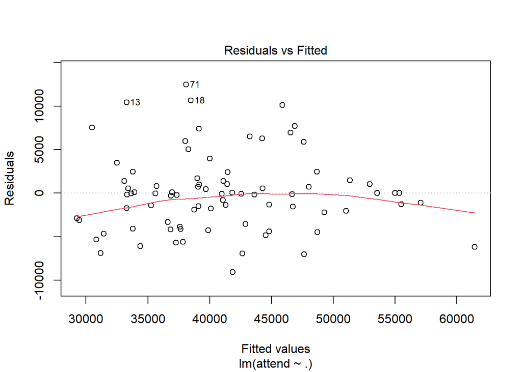

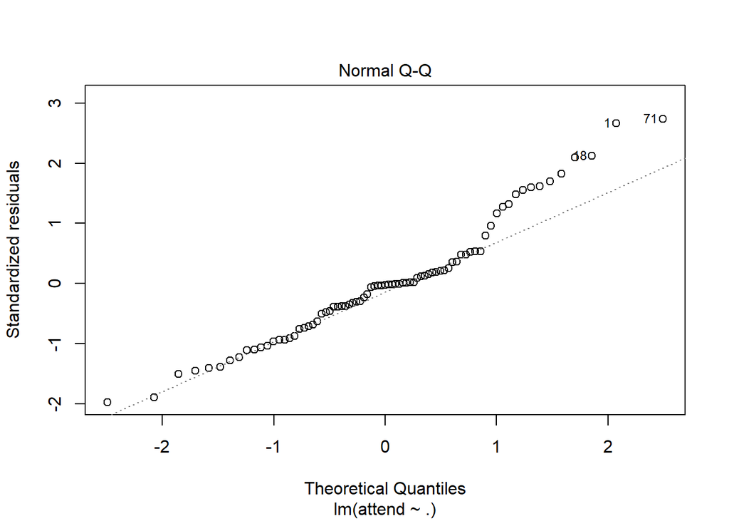

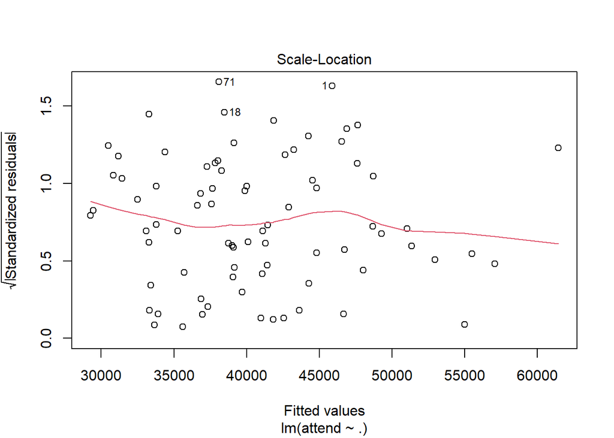

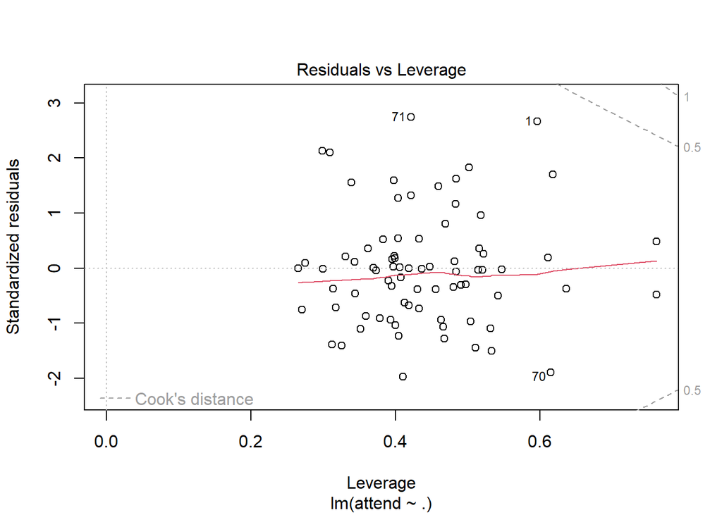

```r
plot(lm1)
```

We want to have our residuals to fitted the line. Also, from the second graph we want our standardized residuals to be as normal distributed as possible.

Here we are investigating our predictors residual plots. It seem like temp need to be modified. To understand about how to modify we make power transformation. However it did not help much. We can observe it from the p-value.

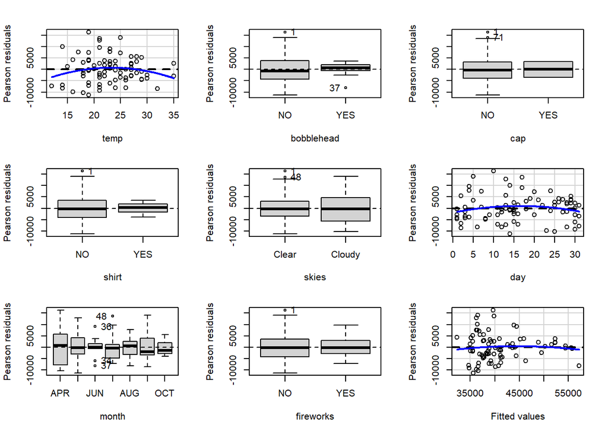

```
##            Test stat Pr(>|Test stat|)
## temp         -1.7860           0.0787 .
## bobblehead
## cap
## shirt
## skies
## day          -1.4096           0.1633
## month
## fireworks
## Tukey test   -0.7281           0.4665
## ---
## Signif. codes:  0 '***' 0.001 '**' 0.01 '*' 0.05 '.' 0.1 ' ' 1
```

```r
lm2<-lm(attend~temp+bobblehead+cap+shirt+skies+day+month+fireworks,data=events)

residualPlots(lm2)
```

```r
pt <- powerTransform(cbind(attend, temp, bobblehead, cap, shirt, skies, day, month, fireworks)~1,data=events)
summary(pt)
```

```
## bcPower Transformations to Multinormality
##            Est Power Rounded Pwr Wald Lwr Bnd Wald Upr Bnd
## attend        1.2602        1.00       0.2284       2.2920
## temp          0.2912        0.00      -0.3574       0.9397
## bobblehead  -10.5719      -10.57     -12.9161      -8.2278
## cap         -58.4291      -58.43     -71.1537     -45.7046
## shirt       -38.9556      -38.96     -47.4393     -30.4720
## skies        -5.6651       -5.67      -7.1571      -4.1731
## day           0.6482        0.50       0.3789       0.9174
## month         0.8286        1.00       0.4630       1.1943
## fireworks    -8.1839       -8.18     -10.0747      -6.2932
##
## Likelihood ratio test that transformation parameters are equal to 0
##  (all log transformations)
##                                            LRT df                   pval
## LR test, lambda = (0 0 0 0 0 0 0 0 0) 1224.133  9 < 0.000000000000000222
##
## Likelihood ratio test that no transformations are needed
##                                            LRT df                   pval
## LR test, lambda = (1 1 1 1 1 1 1 1 1) 1409.702  9 < 0.000000000000000222
```

As we can see from summary, log(temp) seems not statistacally significant.

```r
lm3 <- lm(attend ~ .-temp+log(temp), data=events)
summary(lm3)
```

```
##
## Call:
## lm(formula = attend ~ . - temp + log(temp), data = events)
##
## Residuals:
##    Min     1Q Median     3Q    Max
##  -9972  -3078      0   1483  12934
##
## Coefficients:
##                       Estimate Std. Error t value Pr(>|t|)
## (Intercept)           37252.76   29189.50   1.276  0.20857
## monthMAY               3035.68    6565.58   0.462  0.64610
## monthJUN              -5534.44   12319.79  -0.449  0.65547
## monthJUL               2166.47    6929.94   0.313  0.75604
## monthAUG               5693.16    8370.18   0.680  0.49996
## monthSEP                789.68    8405.14   0.094  0.92557
## monthOCT               2697.70   10151.30   0.266  0.79167
## day                     129.78     141.25   0.919  0.36321
## day_of_weekTuesday     8601.94    2942.15   2.924  0.00545 **
## day_of_weekWednesday    -15.69    2759.15  -0.006  0.99549
## day_of_weekThursday     689.54    3885.20   0.177  0.85995
## day_of_weekFriday    -17987.81    9185.82  -1.958  0.05656 .
## day_of_weekSaturday    3765.46    3337.70   1.128  0.26537
## day_of_weekSunday       713.24    4790.82   0.149  0.88233
## opponentAstros       -21189.87   14137.44  -1.499  0.14105
## opponentBraves       -20587.31   13833.39  -1.488  0.14382
## opponentBrewers      -24153.69   15040.26  -1.606  0.11544
## opponentCardinals    -14174.90   13040.11  -1.087  0.28295
## opponentCubs         -11607.94   12622.53  -0.920  0.36279
## opponentGiants       -18317.56   13170.05  -1.391  0.17127
## opponentMarlins      -19793.42   13849.68  -1.429  0.16002
## opponentMets          -5302.86    6457.65  -0.821  0.41597
## opponentNationals     -8950.22   14229.85  -0.629  0.53262
## opponentPadres       -12382.41   11284.81  -1.097  0.27850
## opponentPhillies     -14392.83   12515.60  -1.150  0.25636
## opponentPirates      -13968.65   13285.33  -1.051  0.29880
## opponentReds         -17157.27   11882.67  -1.444  0.15585
## opponentRockies      -18326.65   12851.11  -1.426  0.16090
## opponentSnakes       -21169.56   12640.45  -1.675  0.10108
## opponentWhite Sox     -1150.88    5730.51  -0.201  0.84175
## skiesCloudy             -10.53    2391.74  -0.004  0.99651
## day_nightNight        -3050.94    3616.00  -0.844  0.40338
## capYES                -6513.97    5851.23  -1.113  0.27164
## shirtYES               1113.30    4588.49   0.243  0.80942
## fireworksYES          20241.24    8335.77   2.428  0.01933 *
## bobbleheadYES          9239.13    3188.81   2.897  0.00584 **
## log(temp)              4471.74   10205.51   0.438  0.66341
## ---
## Signif. codes:  0 '***' 0.001 '**' 0.01 '*' 0.05 '.' 0.1 ' ' 1
##
## Residual standard error: 5966 on 44 degrees of freedom
## Multiple R-squared:  0.7156, Adjusted R-squared:  0.483
## F-statistic: 3.076 on 36 and 44 DF,  p-value: 0.0002329
```

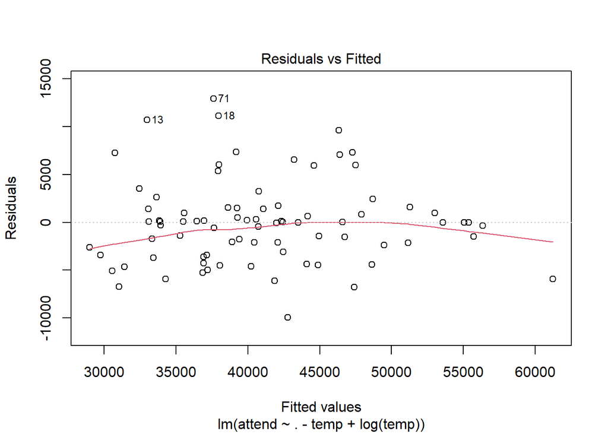

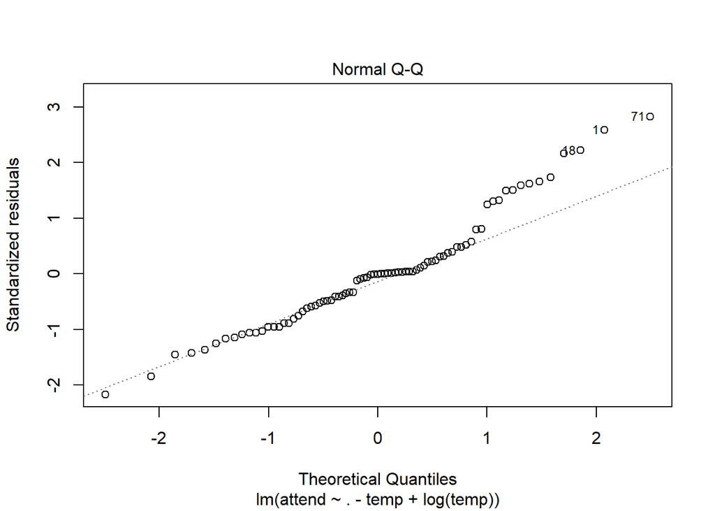

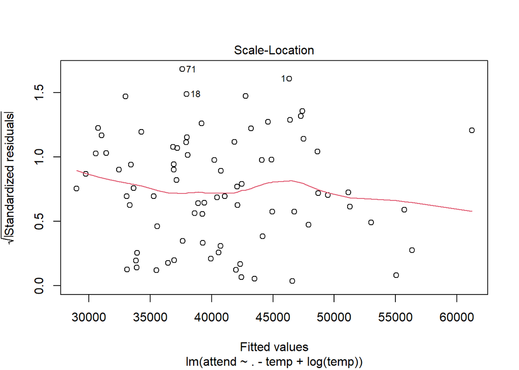

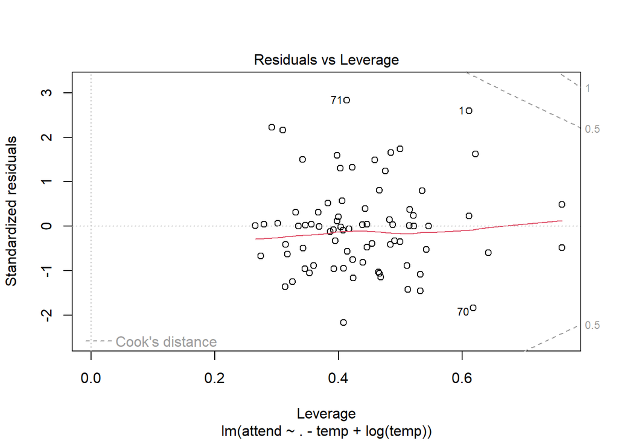

```r
plot(lm3)
```

To make the temp fit the straight line, we need to mutate it to polynomial. We can take a square of temp.

```r
lm4 <- lm(attend ~ .-temp+poly(temp,2), data=events)
summary(lm4)
```

```
##
## Call:
## lm(formula = attend ~ . - temp + poly(temp, 2), data = events)
##
## Residuals:
##    Min     1Q Median     3Q    Max
##  -9792  -2840    -60   1430  11941
##
## Coefficients:
##                      Estimate Std. Error t value Pr(>|t|)
## (Intercept)           54301.4    14233.7   3.815 0.000431 ***
## monthMAY              -1855.0     6983.0  -0.266 0.791777
## monthJUN              -8796.4    12218.7  -0.720 0.475474
## monthJUL              -2726.4     7339.2  -0.371 0.712098
## monthAUG                916.4     8656.7   0.106 0.916189
## monthSEP              -2389.2     8409.1  -0.284 0.777684
## monthOCT              -1335.1    10196.1  -0.131 0.896430
## day                     109.5      138.5   0.790 0.433600
## day_of_weekTuesday     7531.2     2939.8   2.562 0.014001 *
## day_of_weekWednesday   -588.3     2716.3  -0.217 0.829551
## day_of_weekThursday     233.4     3803.5   0.061 0.951359
## day_of_weekFriday    -18459.3     8983.7  -2.055 0.046011 *
## day_of_weekSaturday    4284.2     3276.2   1.308 0.197940
## day_of_weekSunday      1421.0     4701.2   0.302 0.763901
## opponentAstros       -18857.3    13897.9  -1.357 0.181912
## opponentBraves       -22512.1    13585.8  -1.657 0.104794
## opponentBrewers      -22800.6    14784.0  -1.542 0.130342
## opponentCardinals    -12818.3    12822.8  -1.000 0.323070
## opponentCubs         -12207.8    12363.9  -0.987 0.328983
## opponentGiants       -17125.0    12937.1  -1.324 0.192591
## opponentMarlins      -19339.0    13555.4  -1.427 0.160898
## opponentMets          -6281.2     6387.0  -0.983 0.330894
## opponentNationals    -13267.6    14193.2  -0.935 0.355119
## opponentPadres       -12934.4    11075.1  -1.168 0.249286
## opponentPhillies     -12746.4    12287.7  -1.037 0.305379
## opponentPirates      -14281.2    13013.0  -1.097 0.278549
## opponentReds         -16968.9    11624.6  -1.460 0.151632
## opponentRockies      -16922.0    12627.0  -1.340 0.187238
## opponentSnakes       -20252.8    12406.9  -1.632 0.109903
## opponentWhite Sox     -2136.5     5633.5  -0.379 0.706369
## skiesCloudy             744.0     2375.0   0.313 0.755597
## day_nightNight        -2744.0     3538.3  -0.776 0.442269
## capYES                -5421.9     5753.0  -0.942 0.351229
## shirtYES               1016.4     4481.4   0.227 0.821645
## fireworksYES          21232.3     8166.7   2.600 0.012730 *
## bobbleheadYES          9671.9     3127.7   3.092 0.003482 **
## poly(temp, 2)1         9964.3    18989.5   0.525 0.602470
## poly(temp, 2)2       -17123.5     9491.1  -1.804 0.078212 .
## ---
## Signif. codes:  0 '***' 0.001 '**' 0.01 '*' 0.05 '.' 0.1 ' ' 1
##
## Residual standard error: 5831 on 43 degrees of freedom
## Multiple R-squared:  0.7346, Adjusted R-squared:  0.5062
## F-statistic: 3.216 on 37 and 43 DF,  p-value: 0.0001463
```

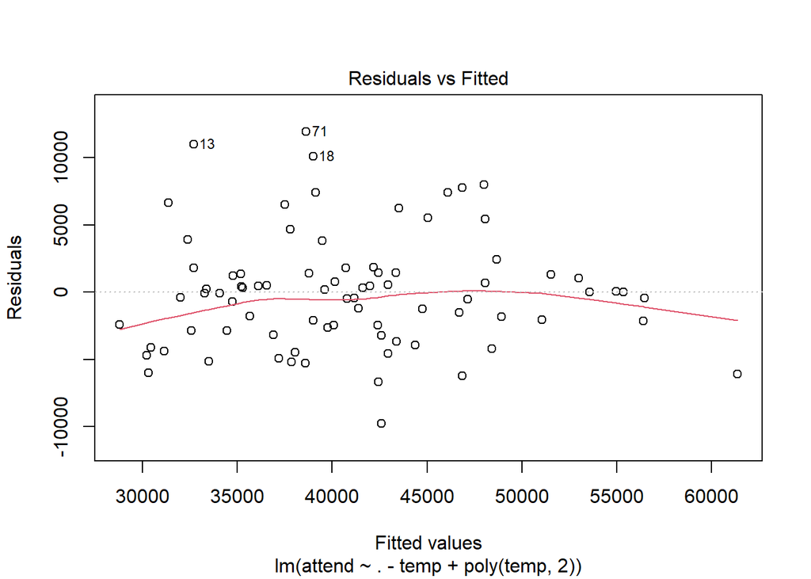

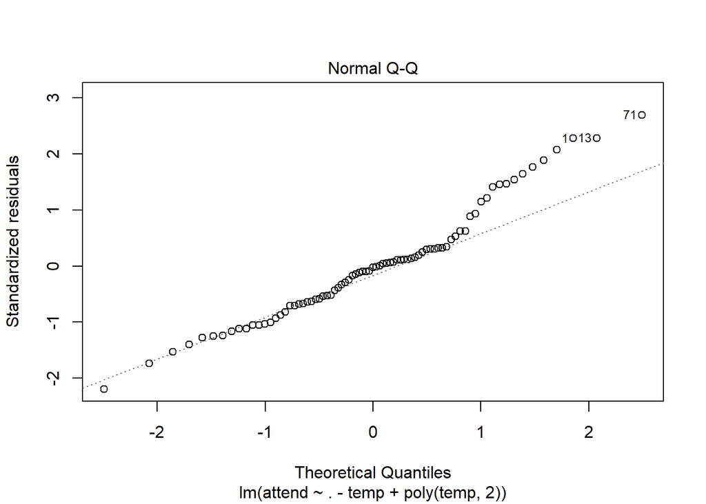

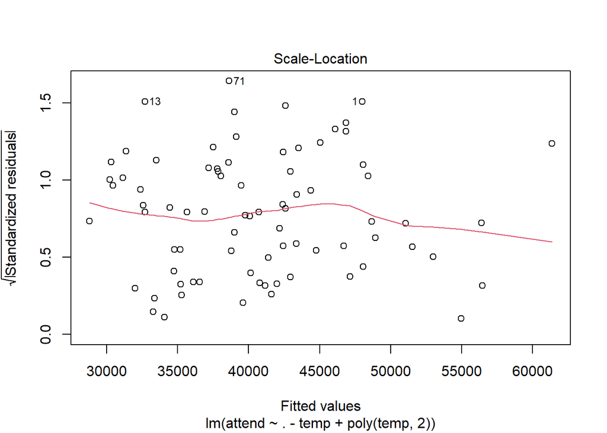

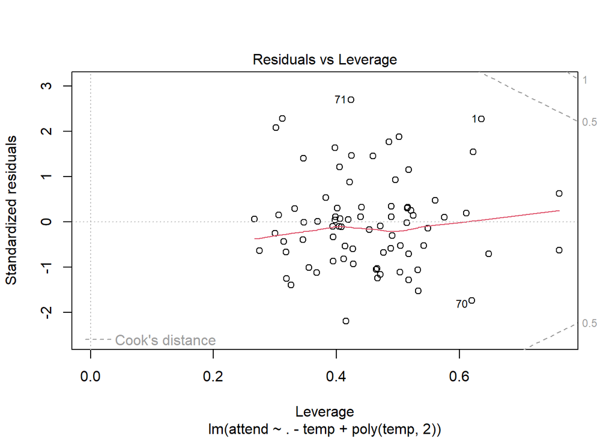

```r
plot(lm4)
```

Here, we can move on with the modified poly(temp, 2) predictor since our Adjusted R-squared value is increased and p-value decreased.

After that operation, as we observed from the lm4 model, we will try to remove some predictors step by step. We will choose removed predictors which are insignificant for our model.

So we created mod5 and mod6. From the summary tables, we can say that there is not much difference on the models but we can comfortably say that both are better than our previous model, lm4, since our Adjusted R-squared value is increased and p-value is decreased.

```r
mod5 <-lm(attend ~ .-temp+poly(temp,2)-day-skies-opponent, data=events)
summary(mod5)
```

```
##
## Call:
## lm(formula = attend ~ . - temp + poly(temp, 2) - day - skies -
##     opponent, data = events)
##
## Residuals:
##    Min     1Q Median     3Q    Max
##  -9334  -3445      0   2441  14565
##
## Coefficients:
##                       Estimate Std. Error t value           Pr(>|t|)
## (Intercept)           36425.86    3665.03   9.939 0.0000000000000225 ***
## monthMAY              -4154.44    2533.13  -1.640           0.106144
## monthJUN               4221.35    2940.11   1.436           0.156173
## monthJUL               -636.37    3173.16  -0.201           0.841718
## monthAUG                -90.27    3390.29  -0.027           0.978846
## monthSEP              -2089.86    4228.00  -0.494           0.622877
## monthOCT              -2379.08    5235.22  -0.454           0.651127
## day_of_weekTuesday     7904.70    2646.51   2.987           0.004055 **
## day_of_weekWednesday   1044.79    2458.82   0.425           0.672394
## day_of_weekThursday    1208.50    3270.17   0.370           0.712995
## day_of_weekFriday    -11208.00    6712.37  -1.670           0.100093
## day_of_weekSaturday    7118.23    2416.66   2.945           0.004560 **
## day_of_weekSunday      6306.69    3292.87   1.915           0.060151 .
## day_nightNight         -743.93    2794.50  -0.266           0.790973
## capYES                -5297.65    4408.12  -1.202           0.234088
## shirtYES               4375.68    3668.86   1.193           0.237624
## fireworksYES          16836.51    6200.61   2.715           0.008601 **
## bobbleheadYES         10221.87    2530.43   4.040           0.000152 ***
## poly(temp, 2)1         6527.91   12223.74   0.534           0.595258
## poly(temp, 2)2       -14968.22    7093.02  -2.110           0.038944 *
## ---
## Signif. codes:  0 '***' 0.001 '**' 0.01 '*' 0.05 '.' 0.1 ' ' 1
##
## Residual standard error: 5657 on 61 degrees of freedom
## Multiple R-squared:  0.6456, Adjusted R-squared:  0.5353
## F-statistic:  5.85 on 19 and 61 DF,  p-value: 0.00000005971
```

```r
mod6 <-lm(attend ~ .-temp+poly(temp,2)-day-skies-opponent-cap-shirt-day_night, data=events)
summary(mod6)
```

```
##
## Call:
## lm(formula = attend ~ . - temp + poly(temp, 2) - day - skies -
##     opponent - cap - shirt - day_night, data = events)
##
## Residuals:
##      Min       1Q   Median       3Q      Max
## -10082.1  -3272.2   -218.6   2439.8  13783.0
##
## Coefficients:
##                      Estimate Std. Error t value             Pr(>|t|)
## (Intercept)           36976.3     2917.4  12.674 < 0.0000000000000002 ***
## monthMAY              -5002.8     2404.1  -2.081              0.04144 *
## monthJUN               3918.3     2931.5   1.337              0.18607
## monthJUL              -2155.1     3022.5  -0.713              0.47844
## monthAUG              -1394.7     3260.2  -0.428              0.67024
## monthSEP              -2437.4     4039.6  -0.603              0.54839
## monthOCT              -3445.5     4978.5  -0.692              0.49139
## day_of_weekTuesday     7360.7     2510.2   2.932              0.00466 **
## day_of_weekWednesday    669.8     2395.0   0.280              0.78065
## day_of_weekThursday     474.8     3231.1   0.147              0.88363
## day_of_weekFriday    -12216.2     6668.5  -1.832              0.07162 .
## day_of_weekSaturday    6588.7     2370.3   2.780              0.00713 **
## day_of_weekSunday      6268.3     2436.1   2.573              0.01241 *
## fireworksYES          17343.7     6181.6   2.806              0.00664 **
## bobbleheadYES         10279.8     2300.5   4.468            0.0000328 ***
## poly(temp, 2)1         7623.8    11646.7   0.655              0.51508
## poly(temp, 2)2       -17226.7     6923.6  -2.488              0.01546 *
## ---
## Signif. codes:  0 '***' 0.001 '**' 0.01 '*' 0.05 '.' 0.1 ' ' 1
##
## Residual standard error: 5660 on 64 degrees of freedom
## Multiple R-squared:  0.6278, Adjusted R-squared:  0.5347
## F-statistic: 6.746 on 16 and 64 DF,  p-value: 0.00000001244
```

Lets compare our models with anova.

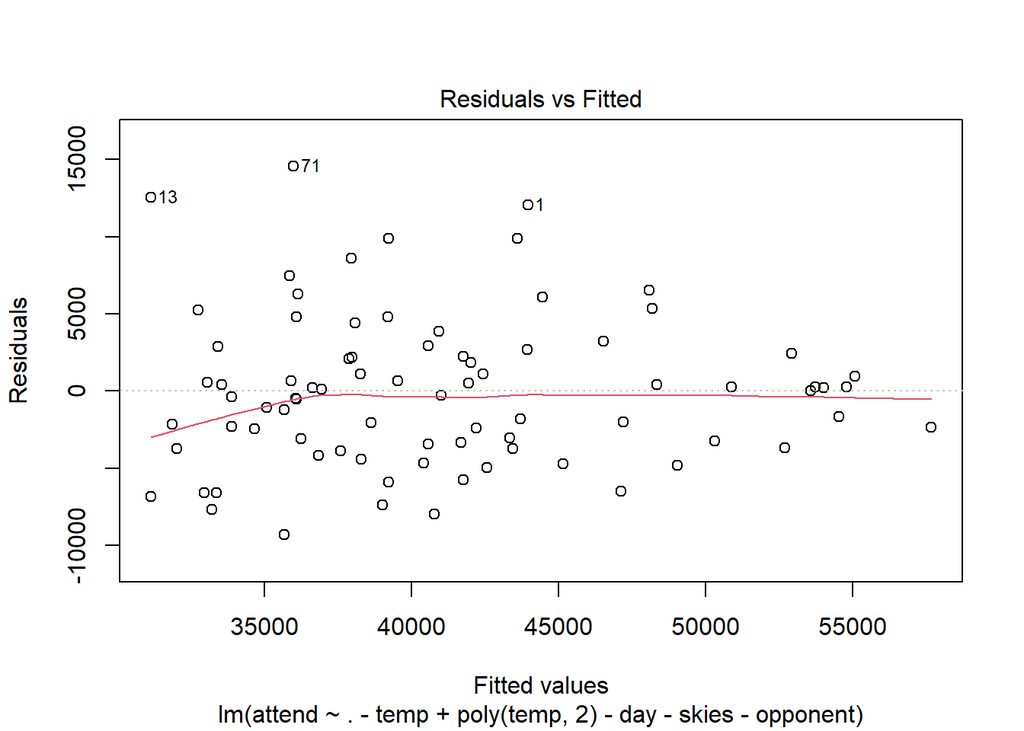

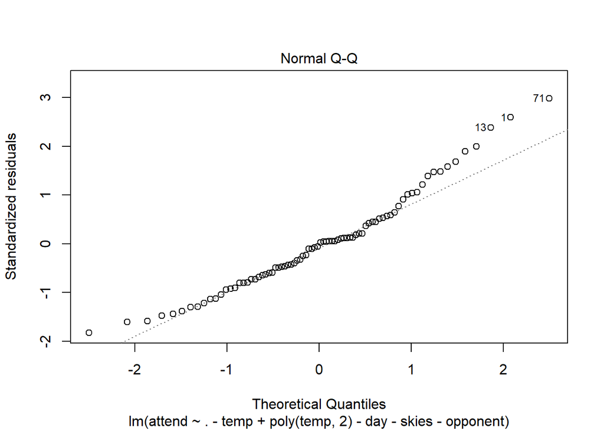

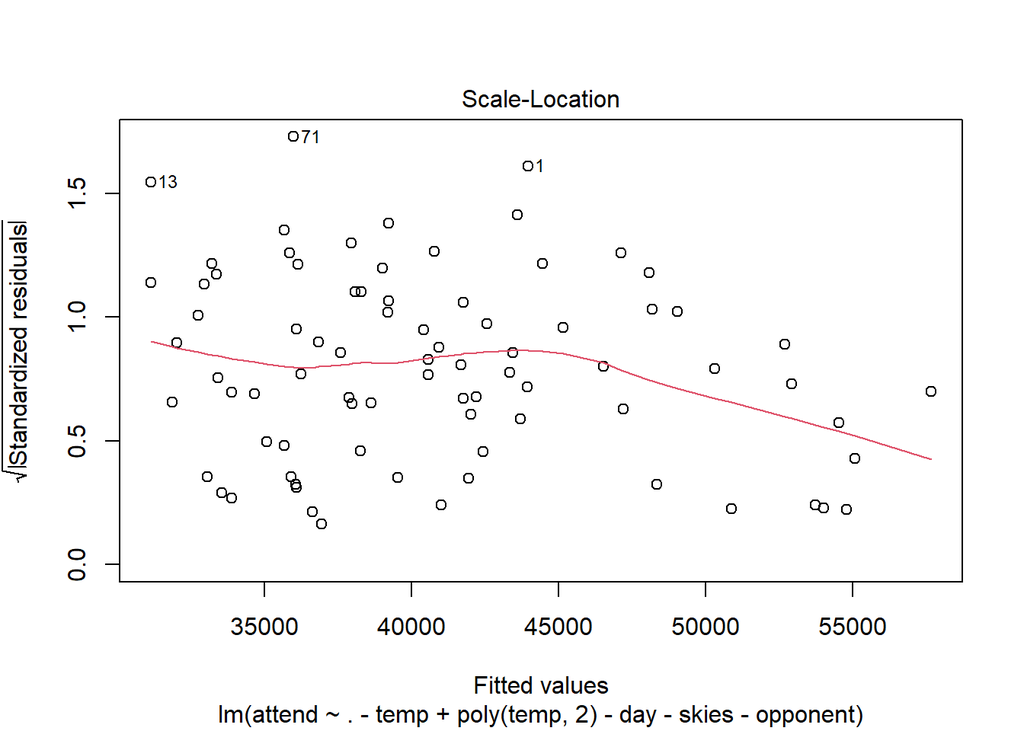

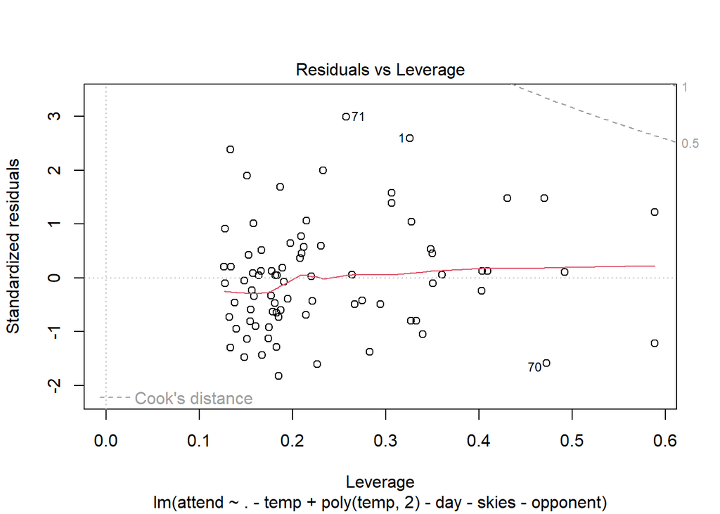

```r
plot(mod5)
```

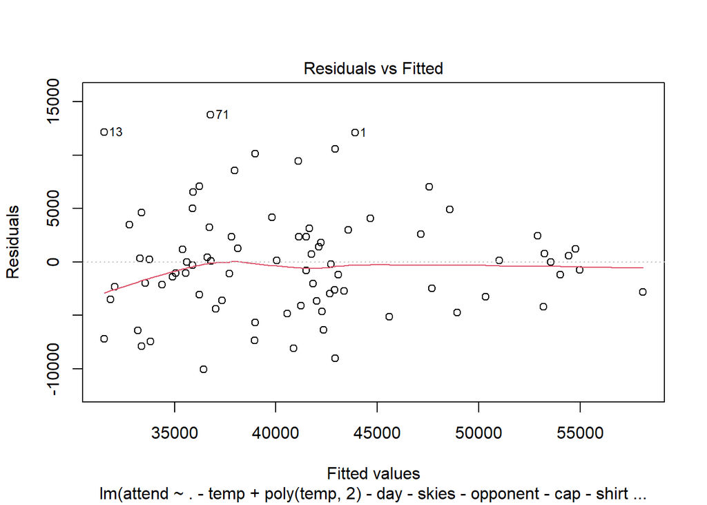

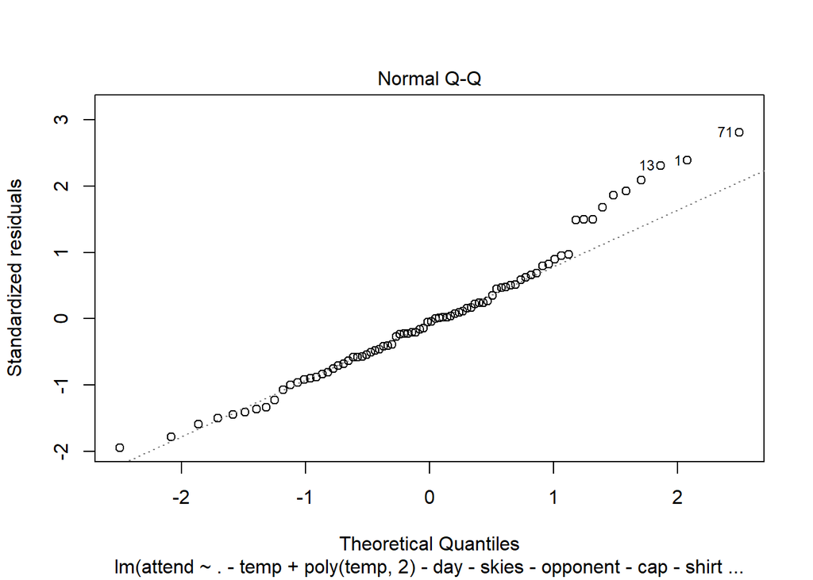

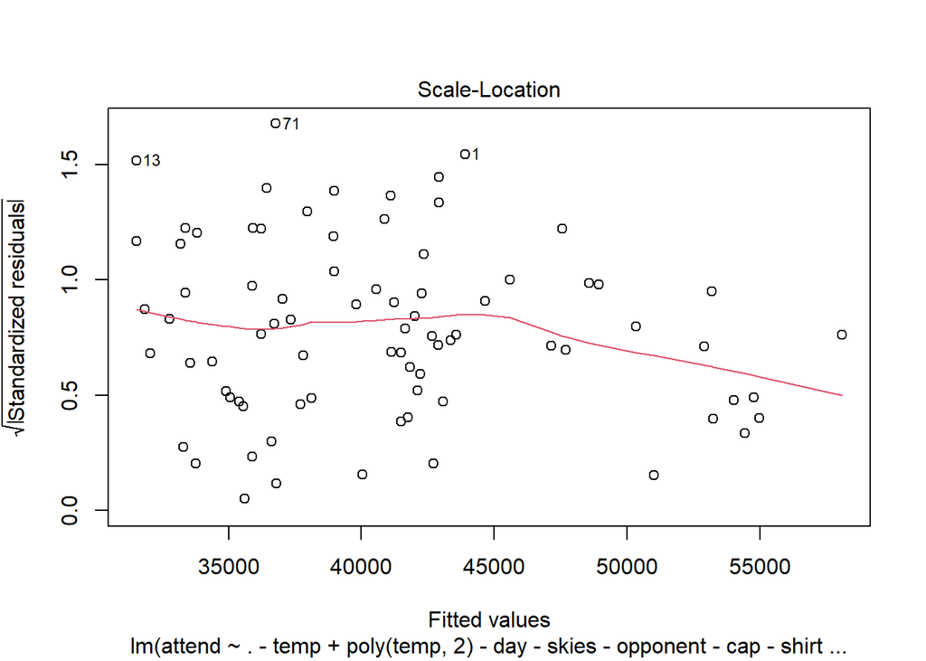

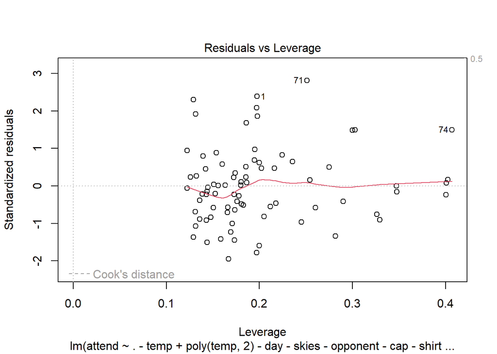

```r
plot(mod6)
```

```r
anova(mod6, mod5, lm4)
```

```
## Analysis of Variance Table
##
## Model 1: attend ~ (month + day + day_of_week + opponent + temp + skies +
##     day_night + cap + shirt + fireworks + bobblehead) - temp +
##     poly(temp, 2) - day - skies - opponent - cap - shirt - day_night
## Model 2: attend ~ (month + day + day_of_week + opponent + temp + skies +
##     day_night + cap + shirt + fireworks + bobblehead) - temp +
##     poly(temp, 2) - day - skies - opponent
## Model 3: attend ~ (month + day + day_of_week + opponent + temp + skies +
##     day_night + cap + shirt + fireworks + bobblehead) - temp +
##     poly(temp, 2)
##   Res.Df        RSS Df Sum of Sq      F Pr(>F)
## 1     64 2050242023
## 2     61 1951767192  3  98474831 0.9654 0.4178
## 3     43 1462021059 18 489746132 0.8002 0.6890
```

```r
AIC(mod6, mod5, lm4)
```

```
##      df      AIC
## mod6 18 1646.657
## mod5 21 1648.670
## lm4  39 1661.268
```

```r
BIC(mod6, mod5, lm4)
```

```
##      df      BIC
## mod6 18 1689.757
## mod5 21 1698.953
## lm4  39 1754.651
```

We can say that these 3 model are not different much and p-value is large so we we can continue with the small model. Also, lower AIC and BIC means better result and we can say that they are agrred on the same model which is mod6. AIC result is more important for us because we want to predict attendance for future games. Therefore, we will move on with mod6.

To improve our model, we can check the interaction between predictors. As we discussed in the class, month and day_of_week interaction provide better result. Also we added the interaction between month and temp. So we added these interaction variables to our model, and use step() function to select a formula-based model by AIC (An Information Criterion).

```r
mod7<- mod6 %>% update(.~.+month:poly(temp,2) + month:day_of_week )%>% step(trace=FALSE,direction="both")
summary(mod7)
```

```
##
## Call:
## lm(formula = attend ~ month + day_of_week + fireworks + bobblehead +
##     poly(temp, 2) + month:day_of_week, data = events)
##
## Residuals:
##    Min     1Q Median     3Q    Max
## -10253  -1909      0   1624  10975
##
## Coefficients: (5 not defined because of singularities)
##                                Estimate Std. Error t value  Pr(>|t|)
## (Intercept)                    30386.46    5862.04   5.184 0.0000107 ***
## monthMAY                        6077.40    6398.72   0.950   0.34913
## monthJUN                       21434.53    7702.99   2.783   0.00885 **
## monthJUL                        3620.74    6482.35   0.559   0.58024
## monthAUG                        2327.30    7528.02   0.309   0.75915
## monthSEP                         194.92    8762.91   0.022   0.98239
## monthOCT                         -22.23    8945.41  -0.002   0.99803
## day_of_weekTuesday             22206.42    6547.05   3.392   0.00182 **
## day_of_weekWednesday            1728.13    6470.61   0.267   0.79107
## day_of_weekThursday             3527.61    7570.24   0.466   0.64429
## day_of_weekFriday              -4114.54   10122.56  -0.406   0.68702
## day_of_weekSaturday            17328.37    6707.86   2.583   0.01441 *
## day_of_weekSunday              14230.61    6755.57   2.107   0.04285 *
## fireworksYES                   16529.43    7773.39   2.126   0.04104 *
## bobbleheadYES                  11036.54    3560.88   3.099   0.00395 **
## poly(temp, 2)1                 21451.57   14736.80   1.456   0.15494
## poly(temp, 2)2                 -4566.51    8656.05  -0.528   0.60134
## monthMAY:day_of_weekTuesday   -22602.85    8157.62  -2.771   0.00911 **
## monthJUN:day_of_weekTuesday   -27886.19   10710.66  -2.604   0.01372 *
## monthJUL:day_of_weekTuesday   -13031.77    7920.62  -1.645   0.10940
## monthAUG:day_of_weekTuesday   -12047.29    9267.33  -1.300   0.20262
## monthSEP:day_of_weekTuesday   -14022.62   10038.38  -1.397   0.17177
## monthOCT:day_of_weekTuesday   -12721.57    9981.76  -1.274   0.21139
## monthMAY:day_of_weekWednesday  -8067.03    8088.04  -0.997   0.32583
## monthJUN:day_of_weekWednesday  -8156.35    9888.75  -0.825   0.41540
## monthJUL:day_of_weekWednesday   1964.02    9140.26   0.215   0.83119
## monthAUG:day_of_weekWednesday   1588.47    8069.01   0.197   0.84514
## monthSEP:day_of_weekWednesday  16832.07   10049.94   1.675   0.10342
## monthOCT:day_of_weekWednesday   -702.28    9948.15  -0.071   0.94415
```

[output cut: 15 more lines]

```
## monthAUG:day_of_weekSaturday   -6500.22    8763.12  -0.742   0.46347
## monthSEP:day_of_weekSaturday  -11346.85    9102.49  -1.247   0.22133
## monthOCT:day_of_weekSaturday         NA         NA      NA        NA
## monthMAY:day_of_weekSunday     -8583.09    7880.17  -1.089   0.28396
## monthJUN:day_of_weekSunday    -12994.55    9933.93  -1.308   0.19988
## monthJUL:day_of_weekSunday     -7403.03    8381.46  -0.883   0.38348
## monthAUG:day_of_weekSunday     -7183.16    8556.28  -0.840   0.40722
## monthSEP:day_of_weekSunday    -14250.37    9365.59  -1.522   0.13764
## monthOCT:day_of_weekSunday           NA         NA      NA        NA
## ---
## Signif. codes:  0 '***' 0.001 '**' 0.01 '*' 0.05 '.' 0.1 ' ' 1
##
## Residual standard error: 5282 on 33 degrees of freedom
## Multiple R-squared:  0.8328, Adjusted R-squared:  0.5947
## F-statistic: 3.498 on 47 and 33 DF,  p-value: 0.000147
```

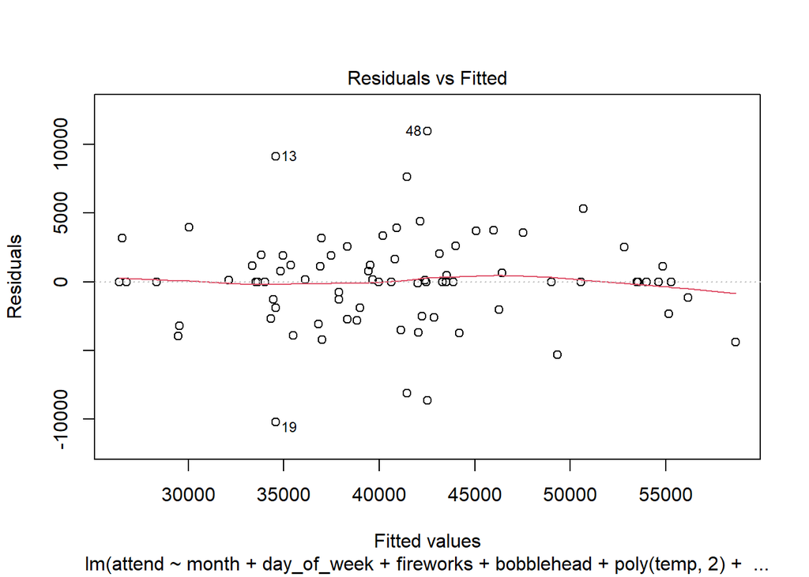

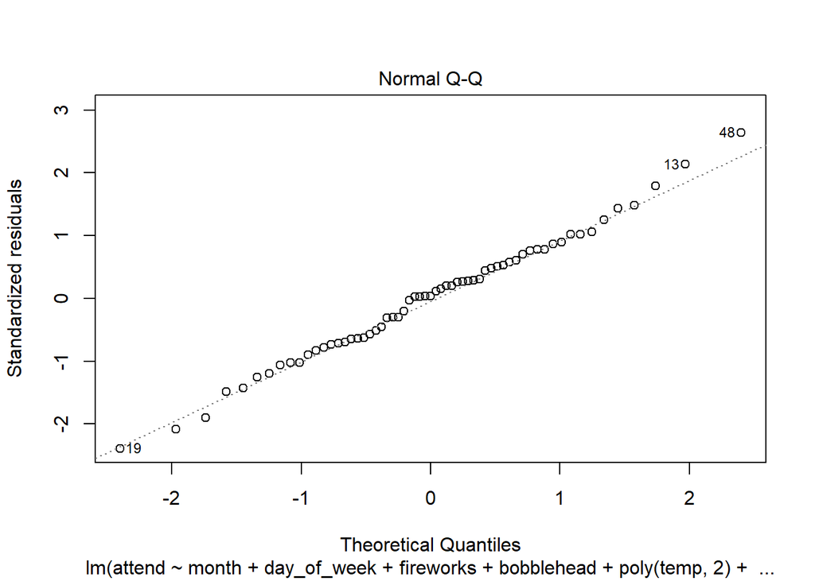

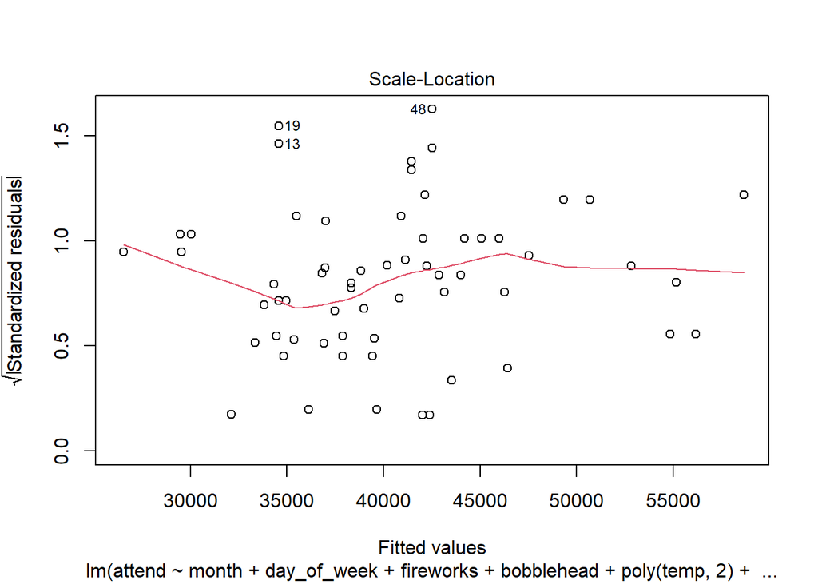

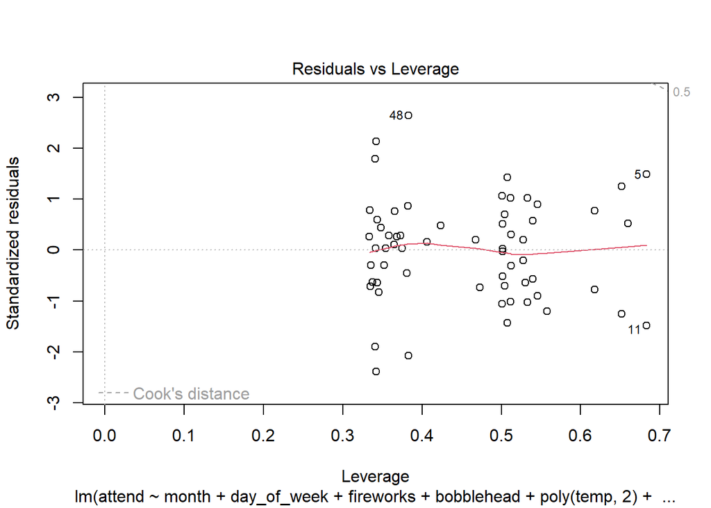

```r
plot(mod7)
```

We can say that mod7 provide us better result when we compare the plots. We apply ncvTest and shapiro test to evaluate our model. For ncvTest, null says the variance is constant. Since p is big (> 0.05), variance is constant. For shapiro test, null says standardized residuals have normal distribution. Since p is big, the residuals seem to have normal distribution.

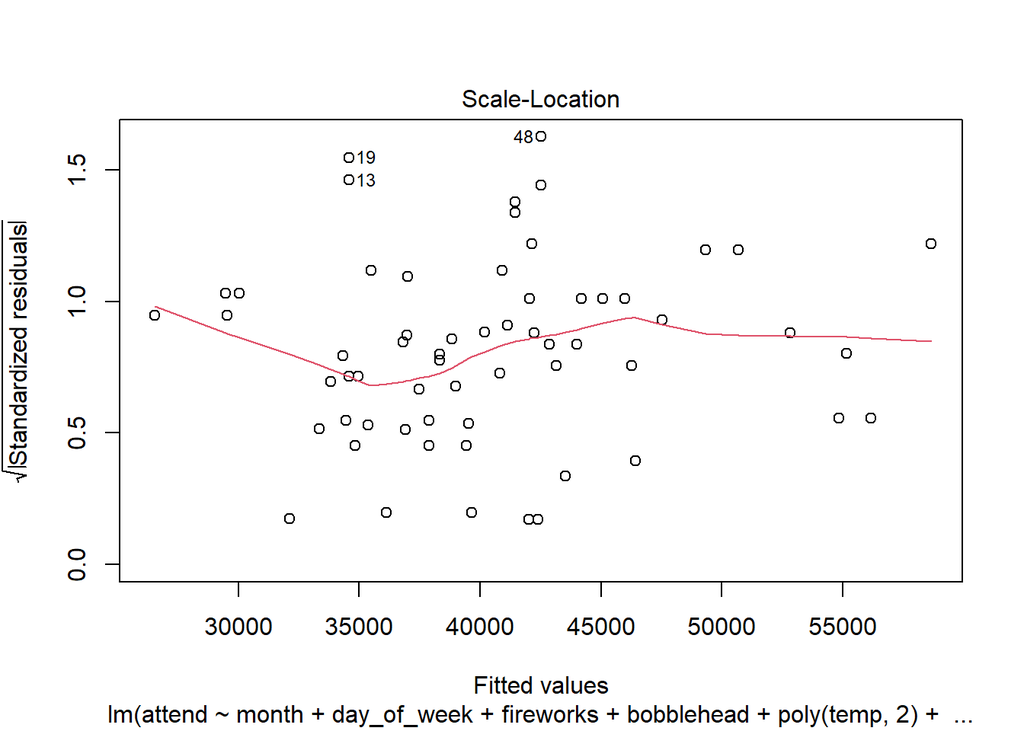

```r
plot(mod7, which = 3)
```

```r
car::ncvTest(mod7)
```

```
## Non-constant Variance Score Test
## Variance formula: ~ fitted.values
## Chisquare = 0.2981257, Df = 1, p = 0.58506
```

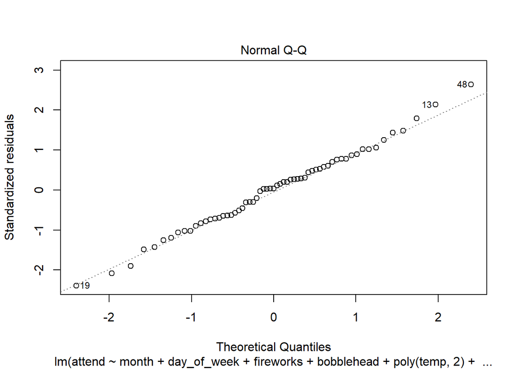

```r
plot(mod7, which = 2)
```

```r
shapiro.test(rstandard(mod7))
```

```
##
##  Shapiro-Wilk normality test
##
## data:  rstandard(mod7)
## W = 0.99356, p-value = 0.9873
```

```r
set.seed(3)

# creating training data as 80% of the dataset
random_sample <- createDataPartition(events$attend,
                                p = 0.8, list = FALSE)

# generating training dataset
# from the random_sample
training_dataset <- events[random_sample, ]

# generating testing dataset
# from rows which are not
# included in random_sample
testing_dataset <- events[-random_sample, ]

# Building the model

# training the model by assigning sales column
# as target variable and rest other columns
# as independent variables
#model <- lm(sales ~., data = training_dataset)
model1 <- update(mod7, data = training_dataset)
model2 <- update(mod6, data = training_dataset)
model3 <- update(mod5, data = training_dataset)

# predicting the target variable
prediction1 <- predict(model1, testing_dataset)
prediction2 <- predict(model2, testing_dataset)
prediction3 <- predict(model3, testing_dataset)

# computing model performance metrics
data.frame( R2 = R2(prediction1, testing_dataset$attend),
            RMSE = RMSE(prediction1, testing_dataset$attend),
            MAE = MAE(prediction1, testing_dataset$attend))
```

```
##          R2     RMSE      MAE
## 1 0.2923382 8352.828 6938.948
```

```r
data.frame( R2 = R2(prediction2, testing_dataset$attend),
            RMSE = RMSE(prediction2, testing_dataset$attend),
            MAE = MAE(prediction2, testing_dataset$attend))
```

```
##         R2     RMSE      MAE
## 1 0.326526 7147.609 5761.488
```

```r
data.frame( R2 = R2(prediction3, testing_dataset$attend),
            RMSE = RMSE(prediction3, testing_dataset$attend),
            MAE = MAE(prediction3, testing_dataset$attend))
```

```
##          R2     RMSE      MAE
## 1 0.2684031 7637.627 6236.079
```

When we checked the results, it contradict with our result. Here we can say that mod6 seems best one among the models. Because it has the max R2, min MAE and min RMSE. Since we do not have big enough data, this may cause a mistake.

Lets check with the AIC and BIC to evaluate models that we consider to use.

```r
AIC(mod5, mod6, mod7)
```

```
##      df      AIC
## mod5 21 1648.670
## mod6 18 1646.657
## mod7 49 1643.815
```

```r
BIC(mod5, mod6, mod7)
```

```
##      df      BIC
## mod5 21 1698.953
## mod6 18 1689.757
## mod7 49 1761.143
```

They do not agree on the same model. AIC says mod7 is better while BIC suggest to use mod6.

```r
100*sigma(mod6)/median(events$attend)
```

```
## [1] 14.05012
```

```r
100*sigma(mod7)/median(events$attend)
```

```
## [1] 13.11242
```

We decided to move with mod7, since it has better plots when we compare with mod6. Also, it’s AIC value is smaller than AIC value of mod6.

*We couldnt predict with the desired conditions. There was a problem about newdata parameter for the predict function.

```r
#predict(object = mod7, newdata = data.frame(month = "JUN", day_of_week = "Wednesday", bobblehead = "YES"), interval = "prediction", level = 0.90)
```